# Chapter 7 Lab: Non-linear Modeling

Your Name

2024-01-05

# Class Workbook

## In class activity

### Ames Housing data

Let’s revisit Ames Hoursing data.

```r
library(AmesHousing)
#?ames_raw
```

### Questions

Use data of `ames_raw` up to 2008 to predict the housing price for the later years.

```r
ames_raw_2008=ames_raw[ames_raw$`Yr Sold`<2008,]
ames_raw_2009=ames_raw[ames_raw$`Yr Sold`>=2008,]
```

Use the same loss function calculator.

```r
calc_loss<-function(prediction,actual){
  difpred <- actual-prediction
  RMSE <-sqrt(mean(difpred^2))
  operation_loss<-abs(sum(difpred[difpred<0]))+sum(0.1*actual[difpred>0])
  return(
    list(RMSE,operation_loss
         )
  )
}
```

Use nonlinear methods discussed in ch 7 of the book. Can you make a better prediction?

Your code:

Your answer:

```
Please write your answer in full sentences.
```

### COVID Data

Let’s revisit COVID data. I’ve divided the data into training and testing data.

```r
Train_COVID<-readRDS("Train_COVID.rds")
Test_COVID<- readRDS( "Test_COVID.rds")
colSums(Train_COVID==98)
```

```
##                USMER         MEDICAL_UNIT                  SEX
##                    0                    0                    0
##         PATIENT_TYPE            DATE_DIED              INTUBED
##                    0                    0                   NA
##            PNEUMONIA                  AGE             PREGNANT
##                   NA                   39                   NA
##             DIABETES                 COPD               ASTHMA
##                  981                  890                  888
##              INMSUPR         HIPERTENSION        OTHER_DISEASE
##                 1010                  933                 1536
##       CARDIOVASCULAR              OBESITY        RENAL_CHRONIC
##                  912                  910                  904
##              TOBACCO CLASIFFICATION_FINAL                  ICU
##                  967                    0                   NA
##             SURVIVED            AGE_TRUNK         SURVIVED_bin
##                    0                   39                    0
```

```r
colSums(Test_COVID==98)
```

[output not shown]

```r
unique(Train_COVID$DIABETES)
```

```
## [1]  2  1 98
```

```r
## Recode missing data as NA #
Train_COVID$ASTHMA  <- ifelse( Train_COVID$ASTHMA  <3, Train_COVID$ASTHMA, NA)
Train_COVID$DIABETES<- ifelse( Train_COVID$DIABETES<3, Train_COVID$DIABETES, NA)
Train_COVID$COPD <- ifelse( Train_COVID$COPD <3, Train_COVID$COPD, NA)
Train_COVID$RENAL_CHRONIC      <- ifelse( Train_COVID$RENAL_CHRONIC <3,  Train_COVID$RENAL_CHRONIC, NA)
Train_COVID$USMER <- ifelse(Train_COVID$USMER < 3, Train_COVID$USMER, NA)
Train_COVID$CARDIOVASCULAR <- ifelse(Train_COVID$CARDIOVASCULAR < 3, Train_COVID$CARDIOVASCULAR, NA)
Train_COVID$HIPERTENSION <- ifelse(Train_COVID$HIPERTENSION < 3, Train_COVID$HIPERTENSION, NA)
Train_COVID$INMSUPR <- ifelse(Train_COVID$INMSUPR < 3, Train_COVID$INMSUPR, NA)


## Factor the variables
Train_COVID$ASTHMA <- ifelse(Train_COVID$ASTHMA < 3, Train_COVID$ASTHMA, NA)
Train_COVID$DIABETES <- ifelse(Train_COVID$DIABETES < 3, Train_COVID$DIABETES, NA)
Train_COVID$COPD <- ifelse(Train_COVID$COPD < 3, Train_COVID$COPD, NA)
Train_COVID$RENAL_CHRONIC <- ifelse(Train_COVID$RENAL_CHRONIC < 3, Train_COVID$RENAL_CHRONIC, NA)
Train_COVID$USMER <- ifelse(Train_COVID$USMER < 3, Train_COVID$USMER, NA)
Train_COVID$CARDIOVASCULAR <- ifelse(Train_COVID$CARDIOVASCULAR < 3, Train_COVID$CARDIOVASCULAR, NA)
Train_COVID$HIPERTENSION <- ifelse(Train_COVID$HIPERTENSION < 3, Train_COVID$HIPERTENSION, NA)
Train_COVID$INMSUPR <- ifelse(Train_COVID$INMSUPR < 3, Train_COVID$INMSUPR, NA)
######
```

Try the method described in Ch7. See if you can improve the performance.

Your code:

```r
# https://www.kaggle.com/datasets/meirnizri/covid19-dataset
#is.factor(Train_COVID$PNEUMONIA)
# previous model:
# glm(SURVIVED_bin ~ AGE_TRUNK + SEX + ASTHMA + DIABETES +
#                       RENAL_CHRONIC + USMER +
#                       MEDICAL_UNIT * PATIENT_TYPE + OBESITY * CARDIOVASCULAR +
#                       HIPERTENSION * INMSUPR + poly(COPD, 2) + I(RENAL_CHRONIC^2),
#                    family=binomial(link = "logit"),
#                    data = Train_COVID)
# fit_1 <- lm(SURVIVED_bin ~ SEX, Train_COVID)
# fit_2 <- lm(SURVIVED_bin ~ poly(SEX, 2), Train_COVID)
# fit_3 <- lm(SURVIVED_bin ~ poly(SEX, 3), Train_COVID)
# fit_4 <- lm(SURVIVED_bin ~ poly(SEX, 4), Train_COVID)
# fit_5 <- lm(SURVIVED_bin ~ poly(SEX, 5), Train_COVID)
#
# table(Train_COVID$ASTHMA)
# #fit <- lm(SURVIVED_bin ~ poly(AGE_TRUNK, 7) + SEX + , Train_COVID)
#
# anova(fit_1, fit_2, fit_3, fit_4, fit_5)
```

Your answer:

[output not shown]

## Problem Set

### College Data

This question relates to the College data set.

```r
data(College,package = "ISLR2")
```

1. Split the data into a training set and a test set. Using out-of-state tuition as the response and the other variables as the predictors. Based on the exercises in the previous chapter, identify a satisfactory model that uses just a subset of the predictors.

Your code:

```r
size <- floor(dim(College)[1]*0.3)
set.seed(1257)
samp_idx <- sample(1:dim(College)[1], size, FALSE)
col_test <- College[samp_idx,]
col_train <- College[-samp_idx,]

col.regfit_full <- regsubsets(Outstate ~., nvmax = 12, col_train)
reg.summary <- summary(col.regfit_full)
reg.summary
```

```
## Subset selection object
## Call: regsubsets.formula(Outstate ~ ., nvmax = 12, col_train)
## 17 Variables  (and intercept)
##             Forced in Forced out
## PrivateYes      FALSE      FALSE
## Apps            FALSE      FALSE
## Accept          FALSE      FALSE
## Enroll          FALSE      FALSE
## Top10perc       FALSE      FALSE
## Top25perc       FALSE      FALSE
## F.Undergrad     FALSE      FALSE
## P.Undergrad     FALSE      FALSE
## Room.Board      FALSE      FALSE
## Books           FALSE      FALSE
## Personal        FALSE      FALSE
## PhD             FALSE      FALSE
## Terminal        FALSE      FALSE
## S.F.Ratio       FALSE      FALSE
## perc.alumni     FALSE      FALSE
## Expend          FALSE      FALSE
## Grad.Rate       FALSE      FALSE
## 1 subsets of each size up to 12
## Selection Algorithm: exhaustive
##           PrivateYes Apps Accept Enroll Top10perc Top25perc F.Undergrad
## 1  ( 1 )  " "        " "  " "    " "    " "       " "       " "
## 2  ( 1 )  " "        " "  " "    " "    " "       " "       " "
## 3  ( 1 )  "*"        " "  " "    " "    " "       " "       " "
## 4  ( 1 )  "*"        " "  " "    " "    " "       " "       " "
## 5  ( 1 )  "*"        " "  " "    " "    " "       " "       " "
## 6  ( 1 )  "*"        " "  " "    " "    " "       " "       " "
## 7  ( 1 )  "*"        " "  " "    " "    " "       " "       " "
## 8  ( 1 )  "*"        " "  "*"    " "    " "       " "       "*"
## 9  ( 1 )  "*"        "*"  "*"    " "    " "       " "       "*"
## 10  ( 1 ) "*"        "*"  "*"    " "    "*"       " "       "*"
## 11  ( 1 ) "*"        "*"  "*"    " "    "*"       " "       "*"
## 12  ( 1 ) "*"        "*"  "*"    " "    "*"       " "       "*"
##           P.Undergrad Room.Board Books Personal PhD Terminal S.F.Ratio
## 1  ( 1 )  " "         " "        " "   " "      " " " "      " "
## 2  ( 1 )  " "         "*"        " "   " "      " " " "      " "
## 3  ( 1 )  " "         "*"        " "   " "      " " " "      " "
## 4  ( 1 )  " "         "*"        " "   " "      "*" " "      " "
## 5  ( 1 )  " "         "*"        " "   " "      "*" " "      " "
## 6  ( 1 )  " "         "*"        " "   " "      "*" " "      " "
## 7  ( 1 )  " "         "*"        " "   " "      "*" " "      "*"
## 8  ( 1 )  " "         "*"        " "   " "      "*" " "      " "
## 9  ( 1 )  " "         "*"        " "   " "      "*" " "      " "
## 10  ( 1 ) " "         "*"        " "   " "      "*" " "      " "
## 11  ( 1 ) " "         "*"        " "   " "      "*" " "      "*"
## 12  ( 1 ) " "         "*"        " "   "*"      "*" " "      "*"
##           perc.alumni Expend Grad.Rate
## 1  ( 1 )  " "         "*"    " "
## 2  ( 1 )  " "         "*"    " "
## 3  ( 1 )  " "         "*"    " "
## 4  ( 1 )  " "         "*"    " "
## 5  ( 1 )  " "         "*"    "*"
## 6  ( 1 )  "*"         "*"    "*"
## 7  ( 1 )  "*"         "*"    "*"
## 8  ( 1 )  "*"         "*"    "*"
## 9  ( 1 )  "*"         "*"    "*"
## 10  ( 1 ) "*"         "*"    "*"
## 11  ( 1 ) "*"         "*"    "*"
## 12  ( 1 ) "*"         "*"    "*"
```

```r
reg.summary$rsq
```

```
##  [1] 0.4294989 0.5826553 0.6736059 0.7112741 0.7289494 0.7381482 0.7414315
##  [8] 0.7477679 0.7521777 0.7566580 0.7590641 0.7609237
```

```r
col.fit_1 <- lm(Outstate ~ Private+Room.Board+perc.alumni+Expend+Grad.Rate+PhD,col_train)
summary(col.fit_1)
```

```
##
## Call:
## lm(formula = Outstate ~ Private + Room.Board + perc.alumni +
##     Expend + Grad.Rate + PhD, data = col_train)
##
## Residuals:
##     Min      1Q  Median      3Q     Max
## -7651.2 -1250.9  -146.4  1276.0 10964.5
##
## Coefficients:
##               Estimate Std. Error t value Pr(>|t|)
## (Intercept) -3.904e+03  5.273e+02  -7.404 5.14e-13 ***
## PrivateYes   2.959e+03  2.511e+02  11.781  < 2e-16 ***
## Room.Board   9.750e-01  9.944e-02   9.805  < 2e-16 ***
## perc.alumni  3.899e+01  8.978e+00   4.343 1.68e-05 ***
## Expend       1.972e-01  2.033e-02   9.701  < 2e-16 ***
## Grad.Rate    2.959e+01  6.667e+00   4.438 1.10e-05 ***
## PhD          4.406e+01  6.748e+00   6.530 1.53e-10 ***
## ---
## Signif. codes:  0 '***' 0.001 '**' 0.01 '*' 0.05 '.' 0.1 ' ' 1
##
## Residual standard error: 2059 on 537 degrees of freedom
## Multiple R-squared:  0.7381, Adjusted R-squared:  0.7352
## F-statistic: 252.3 on 6 and 537 DF,  p-value: < 2.2e-16
```

Your answer:

```
R-square statistic suggests  5 or 6 variables thus I choose subset of Private, Room.Board, perc.alumni, Expend, Grad.Rate, PhD.
```

2. Fit a GAM on the training data, using out-of-state tuition as the response and the features selected in the previous step as the predictors. Plot the results, and explain your findings.

Your code:

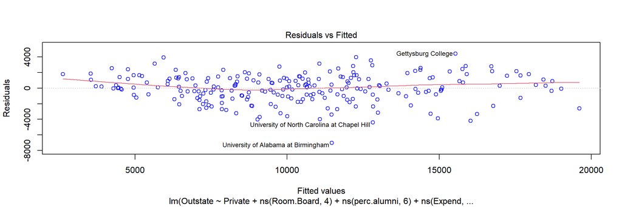

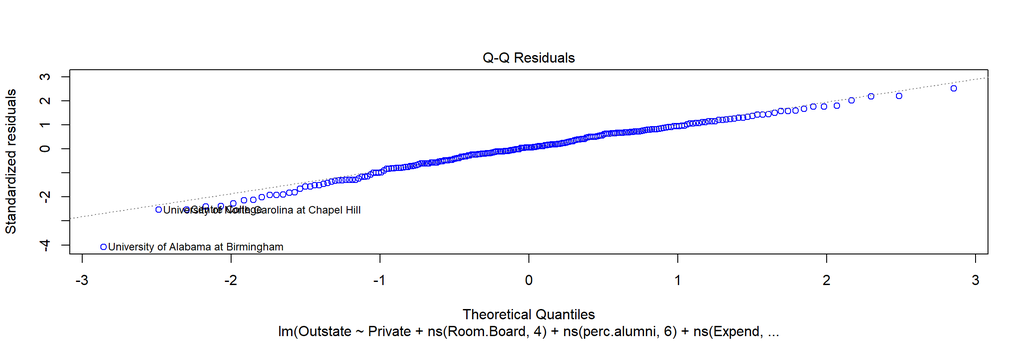

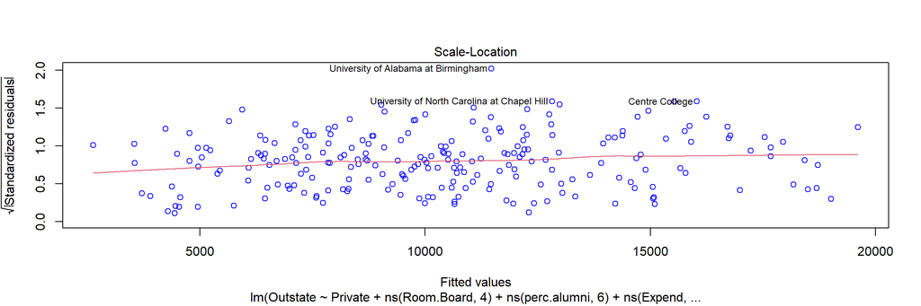

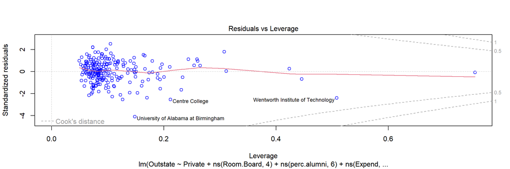

```r
# table(cut(col_test$Room.Board, 4))
# table(cut(col_test$Grad.Rate, 5))
# table(cut(col_test$PhD, 6))
# attr(bs(col_test$PhD, df = 7), "knots")
# table(cut(col_test$perc.alumni, 6))
# table(cut(col_test$Expend, 4))
# attr(bs(col_test$Expend, df = 6), "knots")
col.gam <- lm(Outstate ~ Private + ns(Room.Board, 4) + ns(perc.alumni, 6) +
                ns(Expend, knots = c(6742, 8420, 10912)) +
                ns(Grad.Rate, 5) + ns(PhD, knots = c(60, 72, 80, 87.6)), col_test)
plot(col.gam, se = TRUE, col = "blue")
```

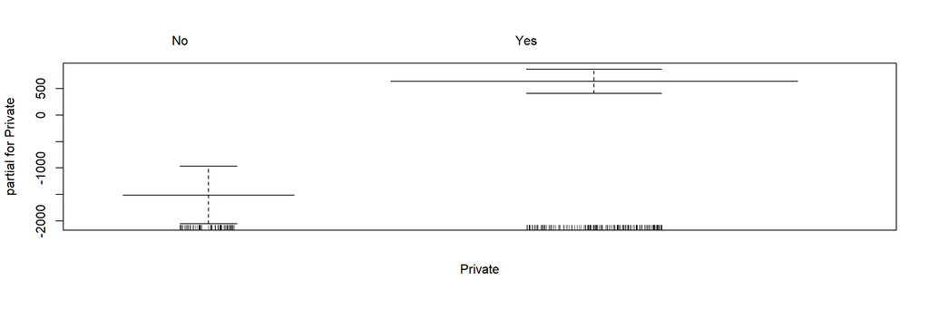

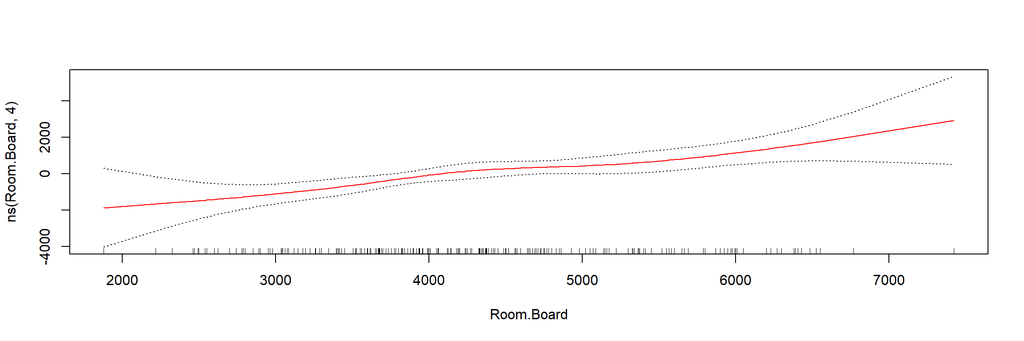

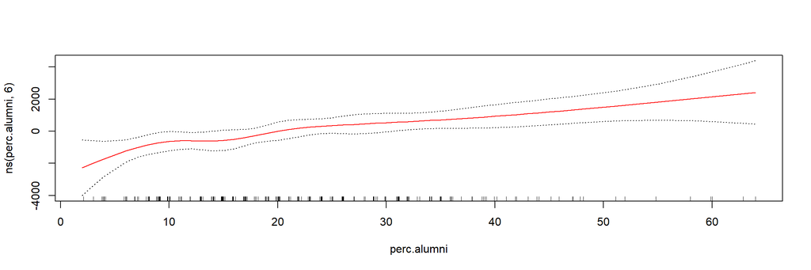

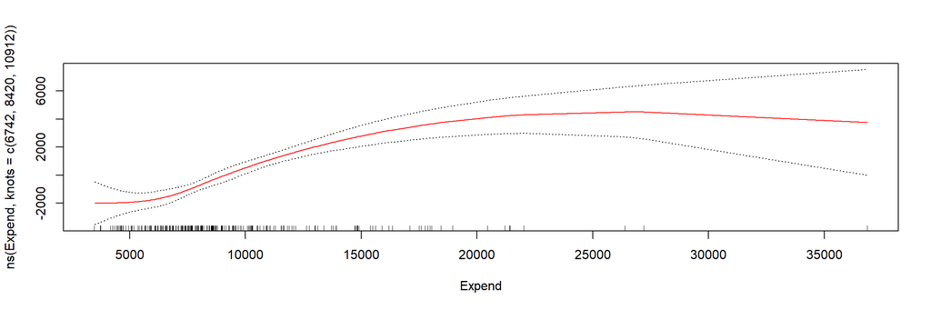

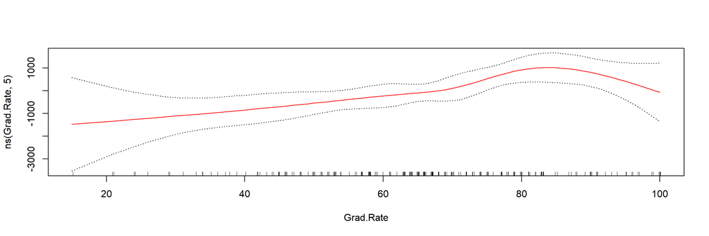

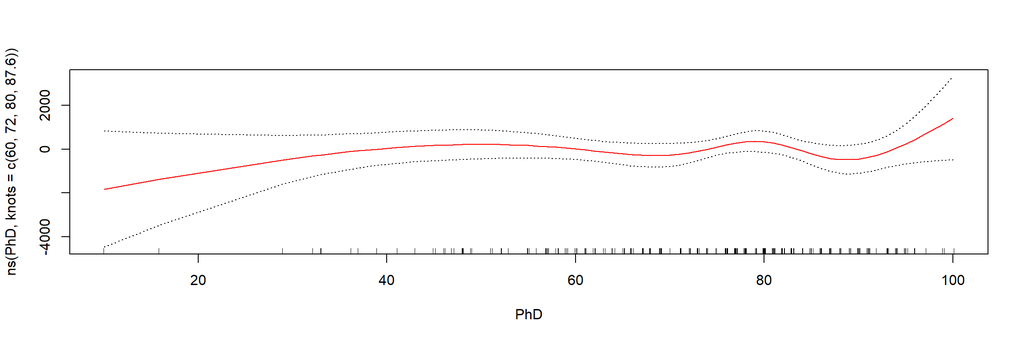

```r
plot.Gam(col.gam, se = TRUE, col = "red")
```

Your answer:

3. Evaluate the model obtained on the test set, and explain the results.

Your code:

```r
summary(col.gam)
```

```
##
## Call:
## lm(formula = Outstate ~ Private + ns(Room.Board, 4) + ns(perc.alumni,
##     6) + ns(Expend, knots = c(6742, 8420, 10912)) + ns(Grad.Rate,
##     5) + ns(PhD, knots = c(60, 72, 80, 87.6)), data = col_test)
##
## Residuals:
##     Min      1Q  Median      3Q     Max
## -7029.6 -1014.4   103.4  1230.2  4431.7
##
## Coefficients:
##                                           Estimate Std. Error t value Pr(>|t|)
## (Intercept)                                 -608.7     2049.3  -0.297 0.766750
## PrivateYes                                  2150.8      386.8   5.561 8.22e-08
## ns(Room.Board, 4)1                          2185.6     1051.3   2.079 0.038862
## ns(Room.Board, 4)2                          1927.8      987.9   1.951 0.052350
## ns(Room.Board, 4)3                          4428.4     2454.8   1.804 0.072686
## ns(Room.Board, 4)4                          4371.7     1352.1   3.233 0.001424
## ns(perc.alumni, 6)1                         1481.6      899.2   1.648 0.100923
## ns(perc.alumni, 6)2                         2442.0     1110.0   2.200 0.028915
## ns(perc.alumni, 6)3                         2705.1     1029.5   2.628 0.009241
## ns(perc.alumni, 6)4                         2405.6      927.0   2.595 0.010139
## ns(perc.alumni, 6)5                         5720.3     2109.0   2.712 0.007245
## ns(perc.alumni, 6)6                         3737.0     1109.9   3.367 0.000906
## ns(Expend, knots = c(6742, 8420, 10912))1   1767.9      838.4   2.109 0.036177
## ns(Expend, knots = c(6742, 8420, 10912))2   7663.4     1131.3   6.774 1.28e-10
## ns(Expend, knots = c(6742, 8420, 10912))3   6667.7     1938.8   3.439 0.000706
## ns(Expend, knots = c(6742, 8420, 10912))4   5748.9     1957.6   2.937 0.003693
## ns(Grad.Rate, 5)1                           1315.3      982.9   1.338 0.182307
## ns(Grad.Rate, 5)2                           1490.0     1241.5   1.200 0.231449
## ns(Grad.Rate, 5)3                           2845.5      865.4   3.288 0.001186
## ns(Grad.Rate, 5)4                           2666.5     2399.6   1.111 0.267756
## ns(Grad.Rate, 5)5                           1053.5      796.6   1.322 0.187476
## ns(PhD, knots = c(60, 72, 80, 87.6))1       1191.2     1276.4   0.933 0.351767
## ns(PhD, knots = c(60, 72, 80, 87.6))2       2692.1     1478.6   1.821 0.070092
## ns(PhD, knots = c(60, 72, 80, 87.6))3       -431.8      995.6  -0.434 0.664945
## ns(PhD, knots = c(60, 72, 80, 87.6))4       4736.7     2953.1   1.604 0.110247
## ns(PhD, knots = c(60, 72, 80, 87.6))5       1671.6     1104.0   1.514 0.131528
##
## (Intercept)
```

[output cut: 16 more lines]

```
## ns(Grad.Rate, 5)2
## ns(Grad.Rate, 5)3                         **
## ns(Grad.Rate, 5)4
## ns(Grad.Rate, 5)5
## ns(PhD, knots = c(60, 72, 80, 87.6))1
## ns(PhD, knots = c(60, 72, 80, 87.6))2     .
## ns(PhD, knots = c(60, 72, 80, 87.6))3
## ns(PhD, knots = c(60, 72, 80, 87.6))4
## ns(PhD, knots = c(60, 72, 80, 87.6))5
## ---
## Signif. codes:  0 '***' 0.001 '**' 0.01 '*' 0.05 '.' 0.1 ' ' 1
##
## Residual standard error: 1863 on 207 degrees of freedom
## Multiple R-squared:  0.814,  Adjusted R-squared:  0.7915
## F-statistic: 36.23 on 25 and 207 DF,  p-value: < 2.2e-16
```

Your answer:

```
Please write your answer in full sentences.
```

4. For which variables, if any, is there evidence of a non-linear relationship with the response?

Your answer:

```
Room.Board, perc.alumni, Expend
```

### Auto Data

Fit some of the non-linear models investigated in chapter 7 to the `Auto` data set. Is there evidence for non-linear relationships in this data set? Create some informative plots to justify your answer.

Your code:

```r
auto <- read.csv("Auto.csv")
auto.regfit_full <- regsubsets(mpg ~ cylinders+displacement+
                                 horsepower+weight+
                                 acceleration+year +origin , auto)
reg.summary <- summary(auto.regfit_full)
reg.summary
```

```
## Subset selection object
## Call: regsubsets.formula(mpg ~ cylinders + displacement + horsepower +
##     weight + acceleration + year + origin, auto)
## 7 Variables  (and intercept)
##              Forced in Forced out
## cylinders        FALSE      FALSE
## displacement     FALSE      FALSE
## horsepower       FALSE      FALSE
## weight           FALSE      FALSE
## acceleration     FALSE      FALSE
## year             FALSE      FALSE
## origin           FALSE      FALSE
## 1 subsets of each size up to 7
## Selection Algorithm: exhaustive
##          cylinders displacement horsepower weight acceleration year origin
## 1  ( 1 ) " "       " "          " "        "*"    " "          " "  " "
## 2  ( 1 ) " "       " "          " "        "*"    " "          "*"  " "
## 3  ( 1 ) " "       " "          " "        "*"    " "          "*"  "*"
## 4  ( 1 ) " "       "*"          " "        "*"    " "          "*"  "*"
## 5  ( 1 ) " "       "*"          "*"        "*"    " "          "*"  "*"
## 6  ( 1 ) "*"       "*"          "*"        "*"    " "          "*"  "*"
## 7  ( 1 ) "*"       "*"          "*"        "*"    "*"          "*"  "*"
```

```r
reg.summary$rsq
```

```
## [1] 0.6926304 0.8081803 0.8174522 0.8180977 0.8200242 0.8211691 0.8214781
```

```r
# The part runs well but cannot knit
# mames <- melt(auto[,c("cylinders","displacement", "horsepower",
#                           "weight" , "acceleration", "name", "year", "origin", "mpg")],
#               id.vars = "mpg")
# ggplot(mames) + geom_point() +
#   aes(x = value, y = mpg) +
#   scale_x_discrete(breaks = pretty_breaks(n = 5)) +
#   facet_wrap(variable~.,scales = "free")+
#   theme_classic()

#table(cut(col_test$Expend, 4))
attr(bs(auto$horsepower, df = 5), "knots")
```

```
## [1]  84 110
```

```r
auto.gam <- lm(mpg~ ns(cylinders, 4) + weight + ns(displacement, knots = c(119, 232)) +
                 ns(horsepower, knots = c(84, 110)) + year + acceleration, auto)
```

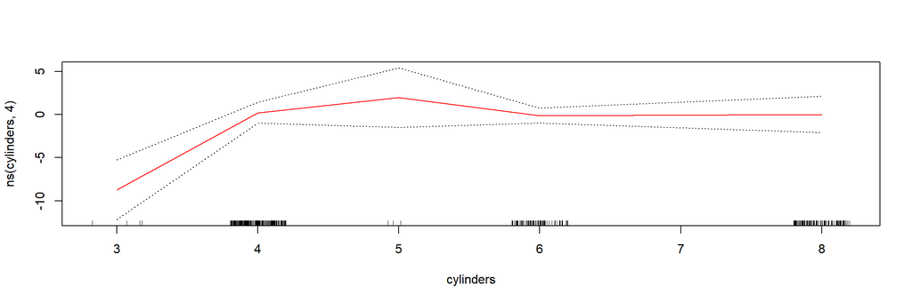

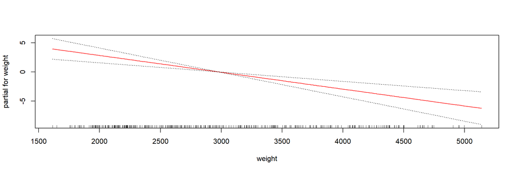

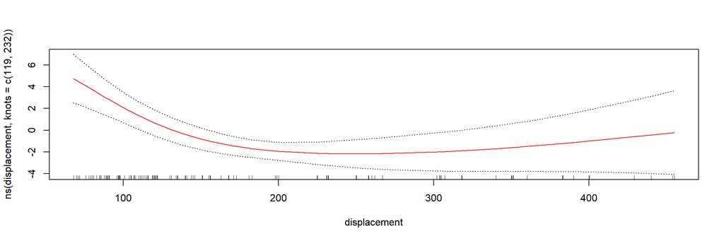

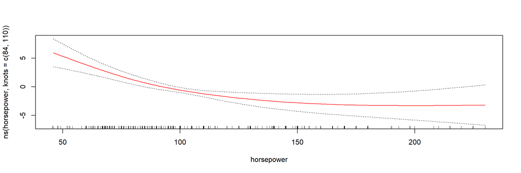

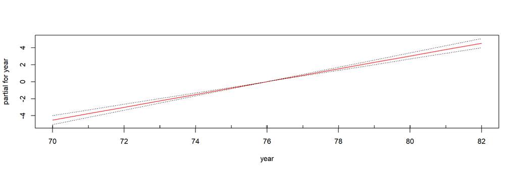

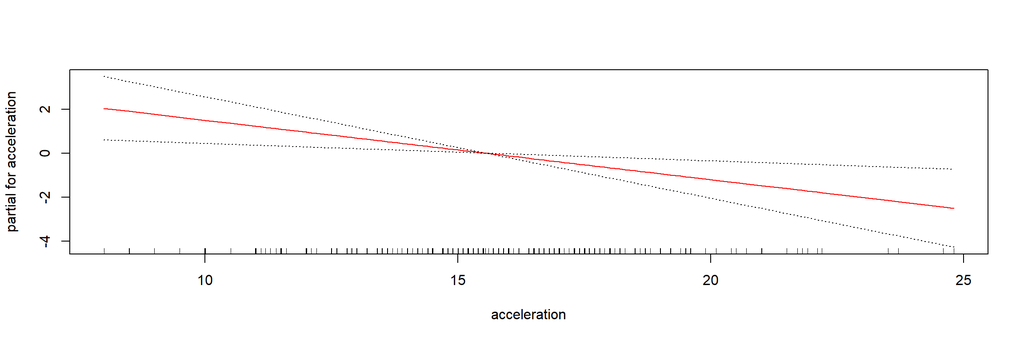

```r
plot.Gam(auto.gam, se = TRUE, col = "red")
```

```r
summary(auto.gam)
```

```
##
## Call:
## lm(formula = mpg ~ ns(cylinders, 4) + weight + ns(displacement,
##     knots = c(119, 232)) + ns(horsepower, knots = c(84, 110)) +
##     year + acceleration, data = auto)
##
## Residuals:
##     Min      1Q  Median      3Q     Max
## -6.7751 -1.6802  0.0368  1.3420 12.1073
##
## Coefficients:
##                                          Estimate Std. Error t value Pr(>|t|)
## (Intercept)                            -1.917e+01  4.270e+00  -4.490 9.47e-06
## ns(cylinders, 4)1                       1.479e+01  5.550e+00   2.665 0.008035
## ns(cylinders, 4)2                       2.445e+00  5.081e+00   0.481 0.630690
## ns(cylinders, 4)3                       1.415e+01  3.780e+00   3.743 0.000210
## ns(cylinders, 4)4                       3.369e+00  1.955e+00   1.723 0.085699
## weight                                 -2.896e-03  6.501e-04  -4.454 1.11e-05
## ns(displacement, knots = c(119, 232))1 -5.614e+00  1.904e+00  -2.949 0.003390
## ns(displacement, knots = c(119, 232))2 -1.124e+01  3.000e+00  -3.748 0.000206
## ns(displacement, knots = c(119, 232))3 -1.893e+00  2.439e+00  -0.776 0.438297
## ns(horsepower, knots = c(84, 110))1    -7.494e+00  1.687e+00  -4.443 1.16e-05
## ns(horsepower, knots = c(84, 110))2    -1.378e+01  2.917e+00  -4.724 3.26e-06
## ns(horsepower, knots = c(84, 110))3    -6.697e+00  2.210e+00  -3.030 0.002613
## year                                    7.558e-01  4.456e-02  16.963  < 2e-16
## acceleration                           -2.705e-01  9.577e-02  -2.824 0.004989
##
## (Intercept)                            ***
## ns(cylinders, 4)1                      **
## ns(cylinders, 4)2
## ns(cylinders, 4)3                      ***
## ns(cylinders, 4)4                      .
## weight                                 ***
## ns(displacement, knots = c(119, 232))1 **
## ns(displacement, knots = c(119, 232))2 ***
## ns(displacement, knots = c(119, 232))3
## ns(horsepower, knots = c(84, 110))1    ***
## ns(horsepower, knots = c(84, 110))2    ***
## ns(horsepower, knots = c(84, 110))3    **
## year                                   ***
## acceleration                           **
## ---
## Signif. codes:  0 '***' 0.001 '**' 0.01 '*' 0.05 '.' 0.1 ' ' 1
##
## Residual standard error: 2.829 on 378 degrees of freedom
## Multiple R-squared:  0.873,  Adjusted R-squared:  0.8686
## F-statistic: 199.9 on 13 and 378 DF,  p-value: < 2.2e-16
```

Your answer:

```
Please write your answer in full sentences.
```

### Backfitting

GAMs are generally fit using a backfitting approach. The idea behind backfitting is quite simple. We will now explore backfitting in the context of multiple linear regression. Suppose we would like to perform multiple linear regression, but we do not have software. Instead, we only have software to perform simple linear regression. Therefore, we take the following iterative approach: we repeatedly hold all but one coefficient estimate fixed at its current value and update only that coefficient estimate using a simple linear regression. The process is continued until convergence—that is, until the coefficient estimates stop changing.We now try this out on a toy example.

1. Generate a response $Y$ and two predictors $X_1$ and $X_2$, with n = 100.
2. Initialize $\hat{\beta}_1$ to take on a value of your choice. It does not matter what value you choose.
3. Keeping $\hat{\beta}_1$ fixed, fit the model $Y-\hat{\beta}_1X_1=\beta_0+\beta_2X_2+\epsilon$ You can do this as follows:

```r
> a <- y - beta1 * x1
> beta2 <- lm(a ~ x2)$coef [2]
```

4. Keeping $\hat{\beta}_2$ fixed, fit the model $Y-\hat{\beta}_2X_2=\beta_0+\beta_1X_1+\epsilon$ You can do this as follows:

```r
> a <- y - beta2 * x2
> beta1 <- lm(a ~ x1)$coef [2]
```

5. Write a for loop to repeat (c) and (d) 1,000 times. Report the estimates of $\hat{\beta}_0$ , $\hat{\beta}_1$ , and $\hat{\beta}_2$ at each iteration of the for loop. Create a plot in which each of these values is displayed, with $\hat{\beta}_0$ , $\hat{\beta}_1$ , and $\hat{\beta}_2$ each shown in a different color.

Your code:

```r
#
#
```

6. Compare your answer in (e) to the results of simply performing multiple linear regression to predict $Y$ using $X_1$ and $X_2$. Use the abline() function to overlay those multiple linear regression coefficient estimates on the plot obtained in (e).

Your code:

```r
#
#
```

Your answer:

```
Please write your answer in full sentences.
```

7. On this data set, how many backfitting iterations were required in order to obtain a “good” approximation to the multiple regression coefficient estimates?

Your code:

```r
#
#
```

Your answer:

```
Please write your answer in full sentences.
```

8. In a toy example with p = 100, show that one can approximate the multiple linear regression coefficient estimates by repeatedly performing simple linear regression in a backfitting procedure. How many backfitting iterations are required in order to obtain a “good” approximation to the multiple regression coefficient estimates? Create a plot to justify your answer.

Your code:

```r
#
#
```

Your answer:

```
Please write your answer in full sentences.
```

### Boston Data

This question uses the variables dis (the weighted mean of distances to five Boston employment centers) and nox (nitrogen oxides concentration in parts per 10 million) from the Boston data. We will treat dis as the predictor and nox as the response. (a) Use the poly() function to fit a cubic polynomial regression to predict nox using dis. Report the regression output, and plot the resulting data and polynomial fits.

Your code:

```r
#
#
```

Your answer:

```
Please write your answer in full sentences.
```

2. Plot the polynomial fits for a range of different polynomial degrees (say, from 1 to 10), and report the associated residual sum of squares.

Your code:

```r
#
#
```

Your answer:

```
Please write your answer in full sentences.
```

3. Perform cross-validation or another approach to select the optimal degree for the polynomial and explain your results.

Your code:

```r
#
#
```

Your answer:

```
Please write your answer in full sentences.
```

4. Use the bs() function to fit a regression spline to predict nox using dis. Report the output for the fit using four degrees of freedom. How did you choose the knots? Plot the resulting fit.

Your code:

```r
#
#
```

Your answer:

```
Please write your answer in full sentences.
```

5. Now fit a regression spline for a range of degrees of freedom, and plot the resulting fits, and report the resulting RSS. Describe the results obtained.

Your code:

```r
#
#
```

Your answer:

```
Please write your answer in full sentences.
```

6. Perform cross-validation or another approach in order to select the best degrees of freedom for a regression spline on this data. Describe your results.

Your code:

```r
#
#
```

Your answer:

```
Please write your answer in full sentences.
```

## Additional Material

### Local regression

Starting with one predictor, we want to estimate a function $f$ that describes the outcome of interest $y$ such that
$$y=f(x)+\epsilon$$
where $\epsilon$ is some error.

In linear regression, we assumed the functional form to be a line
$$f(x)=\alpha+\beta x$$
where $\alpha$ is the intercept and $\beta$ is the slope. This simplification allowed us to summarize the relationship between the two variables using just one number $\beta$. In reality, this is a gross simplification, and in particular, when prediction accuracy is more important than the description of the trend in the relationship, we may want to use more flexible methods.

For example, if your data looks like the following. What do you do?

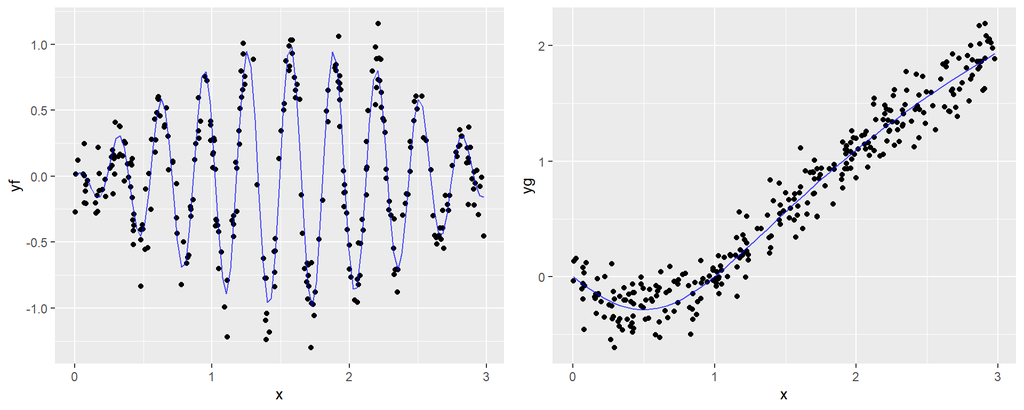

clearly, linear relation does not hold globally. Even in such cases, we could look at local relationships and then sew them together to get a global picture.

#### Running means or the nearest neighbor

The simplest way to estimate $f$ at $x_i$ locally is by averaging the $y$s corresponding to $x$s near $x_i$.
$$\hat{f}(x_i)=\sum_{j\in N(x_i)} y_j /
n_i$$
where $N(x_i)$ indexes $n_i$ neighbors of $x_i$.

$N(x_i)$ can be defined as you wish, but the most popular choice is to use a symmetric neighborhood consisting of the nearest $2k + 1$ points:

$$N(x_i) = { max(i-k, 1), \dots, i-1, i, i
+ 1,\dots, min(i+k, n) }.$$

For example, if we were to use the 10 closest points so that

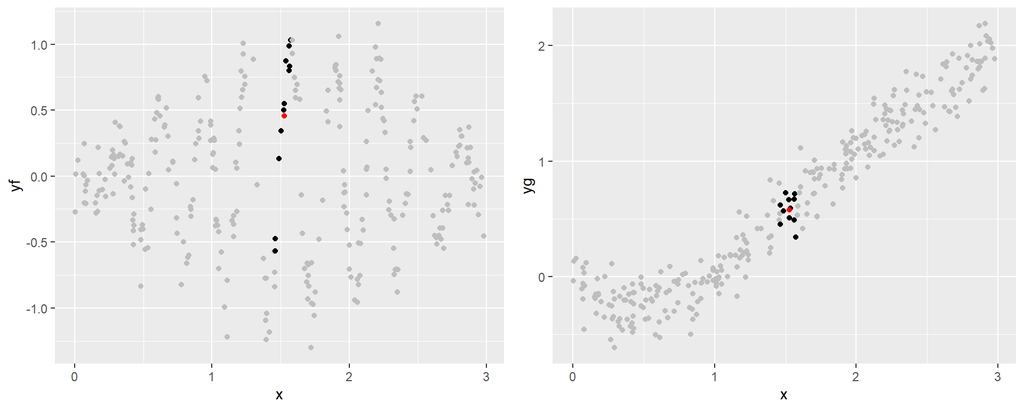

If we keep repeating the procedure for each point and connect the dots together, we get.

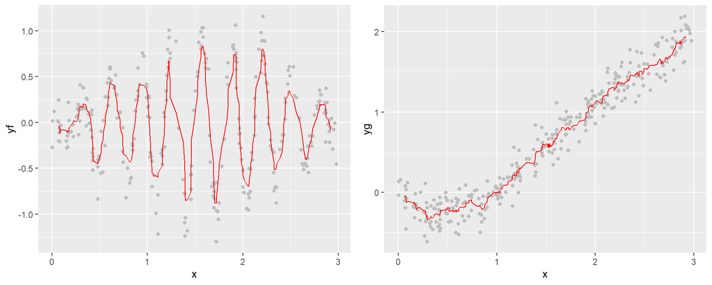

It looks surprisingly well on the left, but it’s clearly too wigly on the right. Usually ends are pretty bad and we can’t use points at the ends that do not have observations.

If we increase the neighborhood size to 20

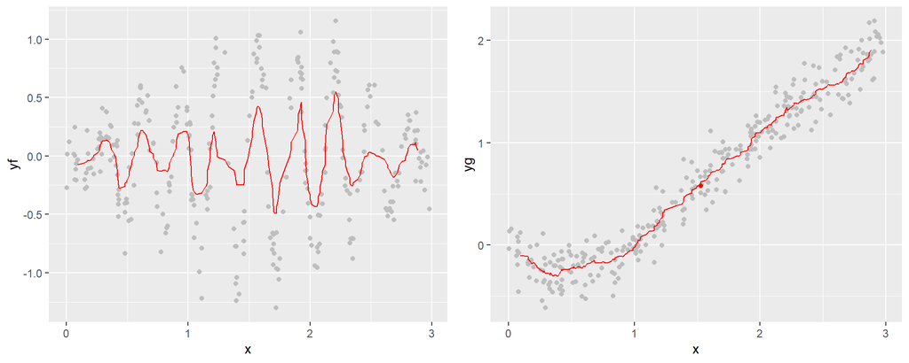

Now the left side is too smooth and the right side looks more decent.

### Running Line

Instead of using a simple mean, we can fit a regression at each neighborhood. Then make a prediction at each $x_i$ so that
$$\hat{f} ( x_i ) = \hat{\alpha}_i + \hat{\beta}_i
x_i ,$$
where $\hat{\alpha}_i$ and $\hat{\beta}_i$ are OLS estimates based on points in a neighborhood $N(x_i)$ of $x_i$. This is actually easy to do thanks to well-known regression updating formulas. Extension to weighted data is obvious. It’s much better than running means.

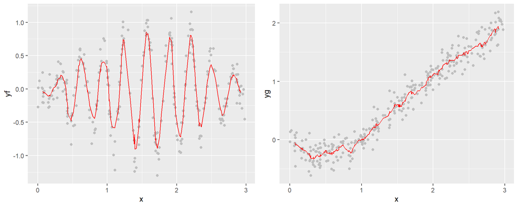

If we were to increase the neighborhood size to 20

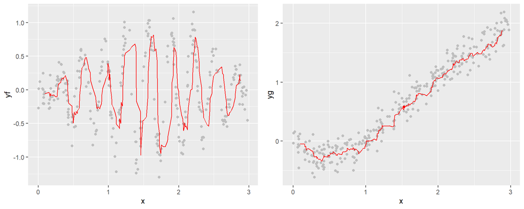

### Weighted running means (Kernel Smoothers)

An alternative approach is to use a weighted running mean, with weights that decline as one moves away from the target value. To calculate $\hat{f}(x_i)$, the $j$th point receives weight
$$w_{ij}=\frac{c_i}{\lambda}d\left(\frac{|x_i-x_j|}{\lambda}\right)$$
,

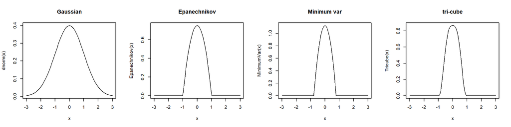

As you can see from the figures, some Kernels are local because there is a border where things don’t matter. Whereas Gaussian kernel is an example of a global Kernel because all the points contribute.

Using Epanechnikov kernel with lambda 0.05 and 0.2.

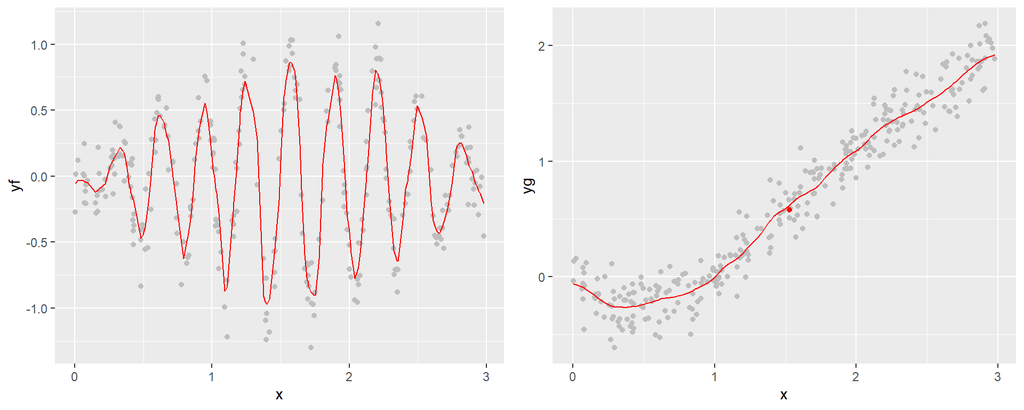

### Loess/Lowess

A variant uses robust regression in each neighborhood.

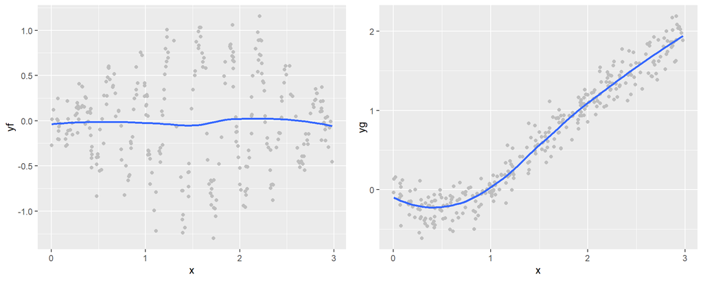

By default setting loess did not work well on the left example. To take into account the small bandwidth you need to specify the span option.

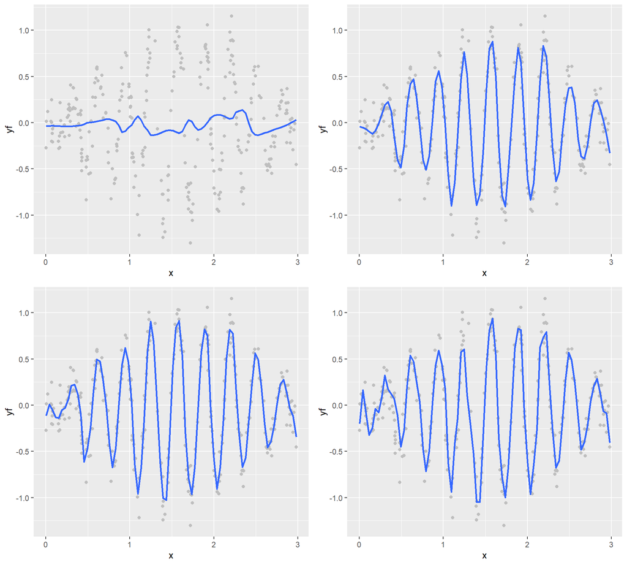

### Other useful functions

Scatter plot smoothing with loess

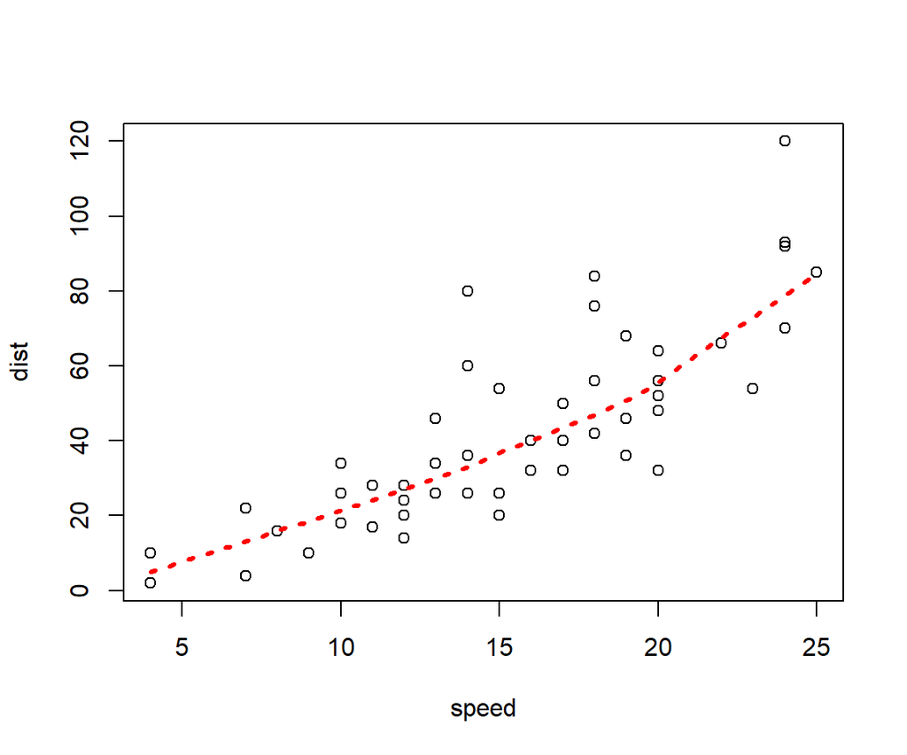

```r
require(graphics)
with(cars, scatter.smooth(speed, dist, lpars =
                    list(col = "red", lwd = 3, lty = 3)))
```

Kernel Regression Smoother

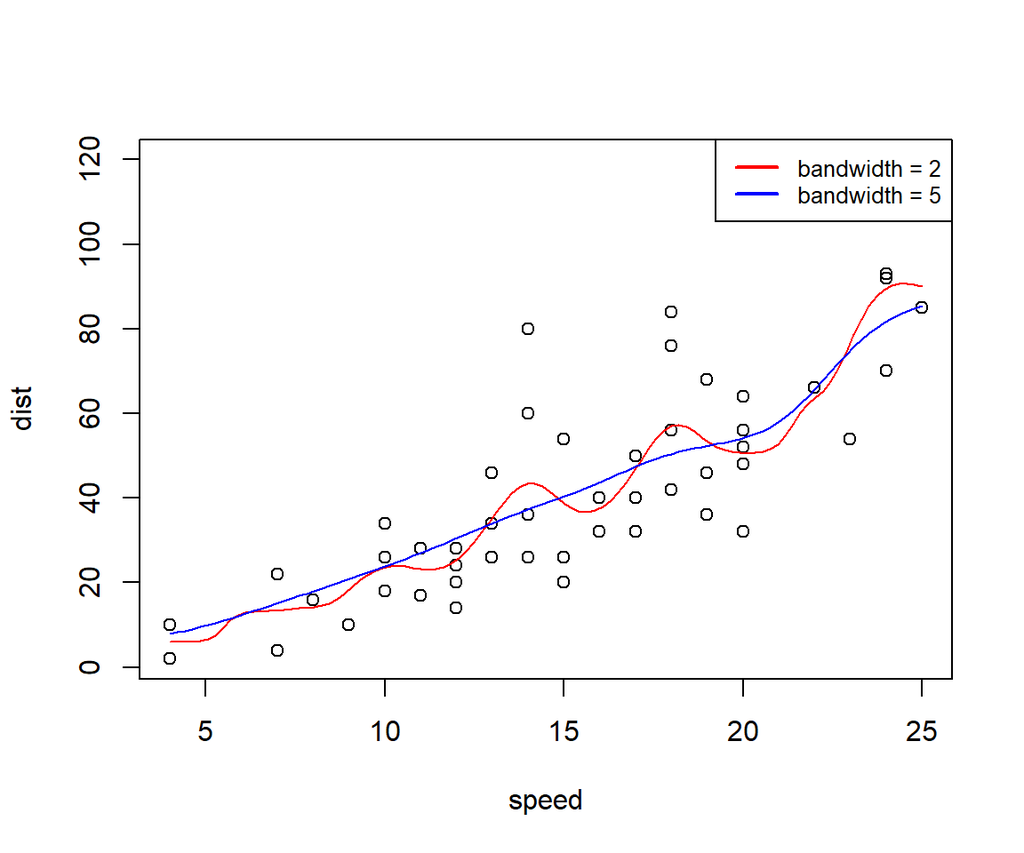

```r
require(graphics)
with(cars, {
    plot(speed, dist)
    lines(ksmooth(speed, dist, "normal", bandwidth = 2), col = "red")
    lines(ksmooth(speed, dist, "normal", bandwidth = 5), col = "blue")
    legend("topright",legend=c("bandwidth = 2","bandwidth = 5"),col=c("red","blue"),lty=1,lwd=2,cex=.8)
})
```

2D Kernel density estimate

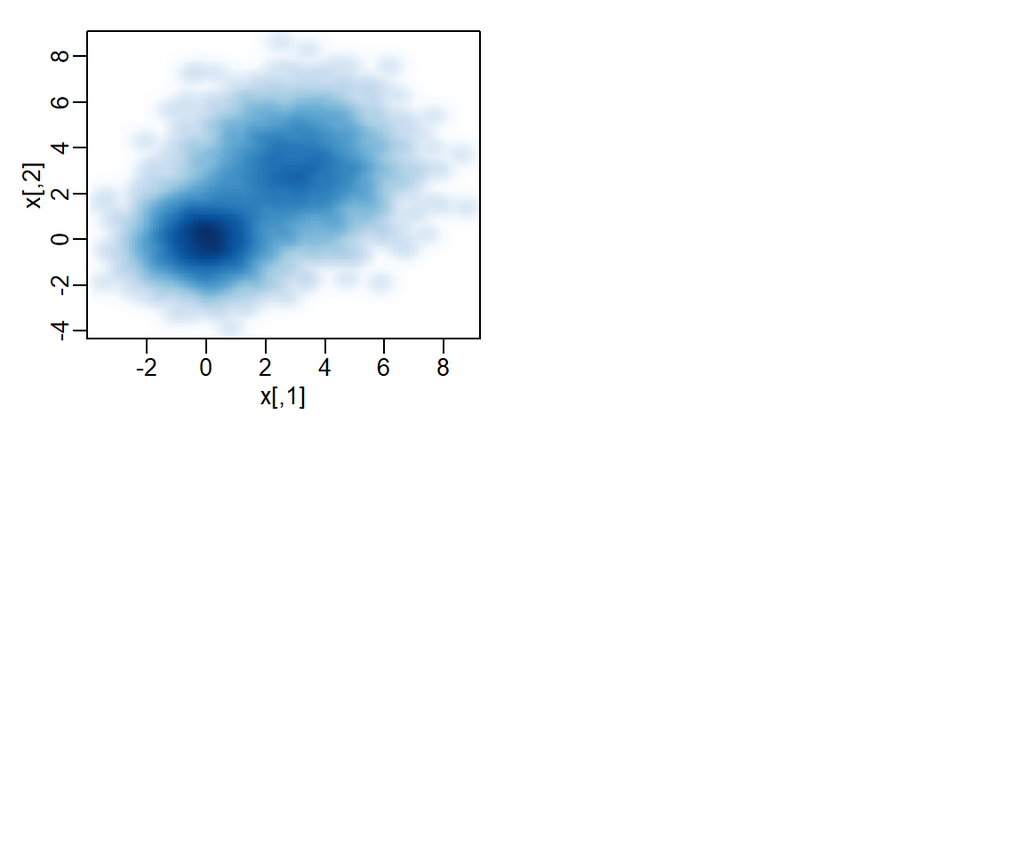

```r
n <- 10000
x1  <- matrix(rnorm(n), ncol = 2)
x2  <- matrix(rnorm(n, mean = 3, sd = 1.5), ncol = 2)
x   <- rbind(x1, x2)

oldpar <- par(mfrow = c(2, 2), mar=.1+c(3,3,1,1), mgp = c(1.5, 0.5, 0))
smoothScatter(x, nrpoints = 0)
```

### Splines

Splines are used for interpolation and smoothing.

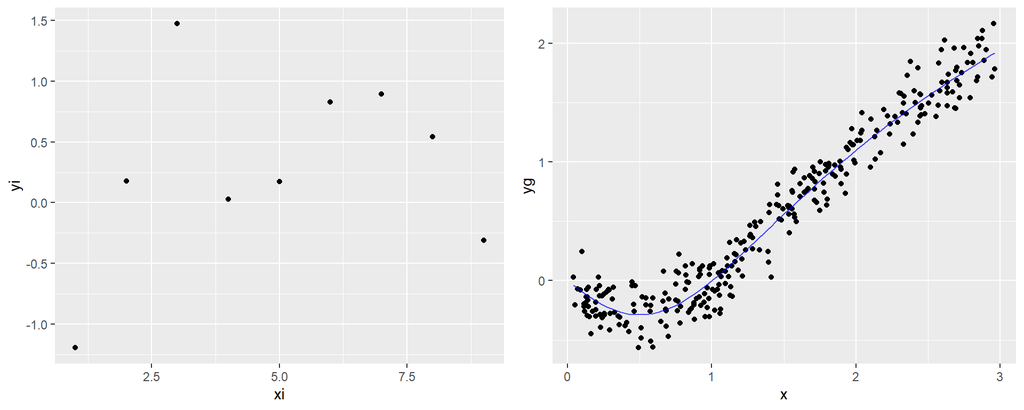

The initial starting point is to fit a straight line and glue them together. We can do so by fitting regression to subset of the data.

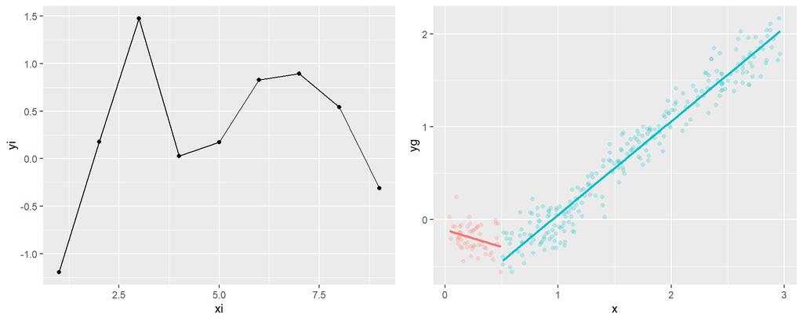

The problem, as apparent from the figure above, is that the result is not necessarily smooth or continuous where the lines meet, which is called the knots. Spline is a popular method to achieve continuity at the knots.